# Formative Assessment 9: Conditional Distributions and Stochastic Independence

APM1110 – Probability and Probability Distributions

Clouie Anne Arces

November 27, 2026

# 1 Title and Introduction

This report applies the ideas of Module 7 — **stochastic independence**, **sums of independent random variables**, and **conditional distributions** — to simulated data in R. Every probability, mean, and variance below is computed in R and, where possible, compared with its theoretical value so that the simulation can be checked against the theory.

The report has four parts:

1. **Stochastic independence** — checking the factorization criterion p<sub>X,Y</sub>(x,y) = p<sub>X</sub>(x)p<sub>Y</sub>(y) for two discrete variables.
2. **Sums of independent random variables** — verifying E[S]=E[X]+E[Y] and Var(S)=Var(X)+Var(Y) for S = X + Y.
3. **Conditional distributions (discrete)** — joint, marginal, and conditional PMFs.
4. **Conditional distributions (continuous)** — joint, marginal, and conditional densities of a bivariate normal pair.

# 2 Simulation Design

All data are simulated, so no external dataset is used. The seed is fixed with `set.seed(1110)`.

| Part | Variables | Distribution and parameters | Sample size |
| --- | --- | --- | --- |
| 1 | X = outcome of a fair six-sided die | Discrete Uniform{1,…,6}, P(X=x)=1/6 | 5,000 |
| 1 | Y = number of heads in 3 fair coin tosses | Binomial(n=3, p=0.5) | 5,000 |
| 2 | X = waiting time for job A (minutes) | Gamma(α=2, λ=0.5) | 10,000 |
| 2 | Y = waiting time for job B (minutes) | Gamma(α=3, λ=0.5) | 10,000 |
| 3 | Y = heads in the first 3 of 5 fair tosses | Binomial(3, 0.5) | 10,000 |
| 3 | X = total heads in all 5 tosses | X = Y + Z, Z∼ Binomial(2, 0.5) | 10,000 |
| 4 | (X, Y) = (study hours, exam score) | Bivariate normal, μ<sub>X</sub>=20, μ<sub>Y</sub>=75, σ<sub>X</sub>=5, σ<sub>Y</sub>=10, ρ=0.7 | 10,000 |

# 3 Stochastic Independence

## 3.1 (a) Description of the variables

```r
n1 <- 5000
X1 <- sample(1:6, n1, replace = TRUE)          # fair die
Y1 <- rbinom(n1, size = 3, prob = 0.5)         # heads in 3 fair tosses
head(data.frame(X = X1, Y = Y1), 8)
```

| X | Y |
| --- | --- |
| 6 | 2 |
| 2 | 2 |
| 1 | 2 |
| 2 | 2 |
| 1 | 2 |
| 6 | 2 |
| 4 | 1 |
| 3 | 3 |

- **X** is the face shown by a fair six-sided die. It is generated with `sample(1:6, replace = TRUE)`, so each value 1,…,6 has probability 1/6.
- **Y** is the number of heads in three tosses of a fair coin. It is generated with `rbinom(n, 3, 0.5)`, so Y∈{0,1,2,3} with probabilities 1/8, 3/8, 3/8, 1/8.

Both are **discrete** random variables. They are generated by separate calls to the random number generator, so the die is never influenced by the coins. The question is whether the *data* show this independence.

## 3.2 (b) Relationship between X and Y

```r
tab1 <- table(X = X1, Y = Y1)
tab1
```

```
   Y
X     0   1   2   3
  1 122 303 293  98
  2 115 297 306  99
  3 108 365 336 112
  4 114 271 317 100
  5 100 325 314  94
  6  88 336 289  98
```

```r
cor(X1, Y1)                                    # sample correlation
```

```
[1] 0.01272285
```

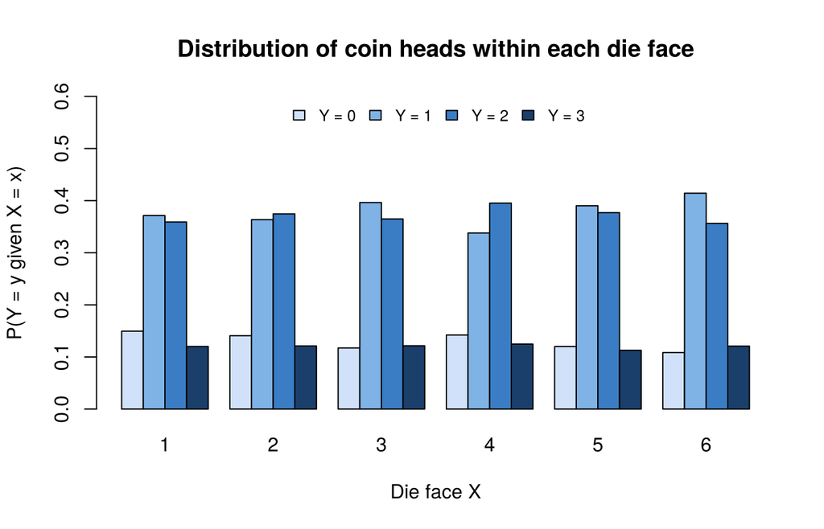

Figure 1. Conditional distribution of Y (coin heads) within each die face. Bars of nearly equal shape across die faces suggest independence.

```r
prop_by_x <- prop.table(tab1, margin = 1)      # P(Y = y | X = x)
barplot(t(prop_by_x), beside = TRUE, col = c("#d0e1f9", "#7fb3e6", "#3b7dc4", "#1b3f6b"),
        legend.text = paste("Y =", 0:3), args.legend = list(x = "top", horiz = TRUE, cex = 0.8, bty = "n"),
        xlab = "Die face X", ylab = "P(Y = y given X = x)", ylim = c(0, 0.6),
        main = "Distribution of coin heads within each die face")
```

The sample correlation is r = 0.0127, which is essentially zero. In Figure 1, the four bars have almost the same heights for every die face: about 1/8, 3/8, 3/8, 1/8. Knowing the die face does not appear to change the distribution of the number of heads.

## 3.3 (c) Joint and marginal PMFs

```r
joint1  <- prop.table(tab1)                    # empirical p_{X,Y}(x, y)
pX1     <- rowSums(joint1)                     # empirical p_X(x)
pY1     <- colSums(joint1)                     # empirical p_Y(y)

round(addmargins(joint1), 4)                   # joint PMF with marginals on the edges
```

```
     Y
X          0      1      2      3    Sum
  1   0.0244 0.0606 0.0586 0.0196 0.1632
  2   0.0230 0.0594 0.0612 0.0198 0.1634
  3   0.0216 0.0730 0.0672 0.0224 0.1842
  4   0.0228 0.0542 0.0634 0.0200 0.1604
  5   0.0200 0.0650 0.0628 0.0188 0.1666
  6   0.0176 0.0672 0.0578 0.0196 0.1622
  Sum 0.1294 0.3794 0.3710 0.1202 1.0000
```

**Table 1.** Empirical joint PMF of (X, Y) with row margins p<sub>X</sub>(x) and column margins p<sub>Y</sub>(y) (`Sum` row and column).

```r
data.frame(x = 1:6, empirical_pX = round(as.numeric(pX1), 4), theoretical_pX = round(1/6, 4))
```

| x | empirical_pX | theoretical_pX |
| --- | --- | --- |
| 1 | 0.1632 | 0.1667 |
| 2 | 0.1634 | 0.1667 |
| 3 | 0.1842 | 0.1667 |
| 4 | 0.1604 | 0.1667 |
| 5 | 0.1666 | 0.1667 |
| 6 | 0.1622 | 0.1667 |

```r
data.frame(y = 0:3, empirical_pY = round(as.numeric(pY1), 4), theoretical_pY = dbinom(0:3, 3, 0.5))
```

| y | empirical_pY | theoretical_pY |
| --- | --- | --- |
| 0 | 0.1294 | 0.125 |
| 1 | 0.3794 | 0.375 |
| 2 | 0.3710 | 0.375 |
| 3 | 0.1202 | 0.125 |

## 3.4 (d) Factorization criterion

X and Y are independent if and only if

p<sub>X,Y</sub>(x,y) = p<sub>X</sub>(x)p<sub>Y</sub>(y) for every pair (x, y).

```r
product1 <- outer(pX1, pY1)                    # p_X(x) * p_Y(y)
diff1    <- joint1 - product1

round(product1, 4)                             # Table 4: product of marginals
```

```
       0      1      2      3
1 0.0211 0.0619 0.0605 0.0196
2 0.0211 0.0620 0.0606 0.0196
3 0.0238 0.0699 0.0683 0.0221
4 0.0208 0.0609 0.0595 0.0193
5 0.0216 0.0632 0.0618 0.0200
6 0.0210 0.0615 0.0602 0.0195
```

```r
round(diff1, 4)                                # Table 5: joint minus product
```

```
   Y
X         0       1       2       3
  1  0.0033 -0.0013 -0.0019  0.0000
  2  0.0019 -0.0026  0.0006  0.0002
  3 -0.0022  0.0031 -0.0011  0.0003
  4  0.0020 -0.0067  0.0039  0.0007
  5 -0.0016  0.0018  0.0010 -0.0012
  6 -0.0034  0.0057 -0.0024  0.0001
```

```r
max_abs_diff <- max(abs(diff1))
max_abs_diff
```

```
[1] 0.00665576
```

```r
chi1 <- chisq.test(tab1)                       # test of independence
chi1
```

```
    Pearson's Chi-squared test

data:  tab1
X-squared = 19.384, df = 15, p-value = 0.1969
```

**Tables 4–5.** Product of the marginals, and its difference from the joint PMF.

The largest gap between p<sub>X,Y</sub>(x,y) and p<sub>X</sub>(x)p<sub>Y</sub>(y) is only **0.0067**. Each joint cell has probability between about 0.02 and 0.06, so this gap is just sampling noise. The chi-square test of independence agrees: χ² = 19.38 with df = 15 and p = 0.1969. Because p > 0.05, we **fail to reject independence**.

**Contrast with a dependent pair.** Suppose a game awards a *bonus* of W = Y + I(X ≥ 5). Then W depends on the die by construction, and the factorization fails:

```r
W1 <- Y1 + (X1 >= 5)
jointXW <- prop.table(table(X1, W1))
gap_dep <- max(abs(jointXW - outer(rowSums(jointXW), colSums(jointXW))))
chisq.test(table(X1, W1))$p.value
```

```
[1] 3.306892e-244
```

For the dependent pair, the largest gap from factorization is about 4.4 times larger (0.0291 vs. 0.0067), and the chi-square p-value is essentially 0.

**Conclusion for Part 1.** The die outcome X and the number of heads Y satisfy the factorization criterion within sampling error: the joint PMF equals the product of the marginals in every cell. So X and Y can reasonably be treated as **stochastically independent**. This also matches how they were generated. The contrast example shows what a failure of factorization looks like when real dependence exists.

# 4 Sums of Independent Random Variables

## 4.1 (a) Distributions of X and Y

- X ∼ Gamma(α = 2, λ = 0.5): the waiting time (in minutes) for job A. Then E[X] = α/λ = 4 and Var(X) = α/λ² = 8.
- Y ∼ Gamma(α = 3, λ = 0.5): the waiting time for job B. Then E[Y] = 6 and Var(Y) = 12.

The two jobs run on separate machines, so X and Y are independent. Because they share the same rate λ, theory says the sum is also Gamma:

S = X + Y ∼ Gamma(α = 2 + 3 = 5, λ = 0.5), E[S] = 10, Var(S) = 20.

## 4.2 (b) Independent generation

```r
n2     <- 10000
alphaX <- 2; alphaY <- 3; rate <- 0.5
X2 <- rgamma(n2, shape = alphaX, rate = rate)  # generated in its own call
Y2 <- rgamma(n2, shape = alphaY, rate = rate)  # separate call -> independent of X2
cor(X2, Y2)                                    # should be ~ 0
```

```
[1] -0.01372794
```

There are n = 10,000 draws of each variable, more than the 5,000 required. Each variable comes from a separate `rgamma()` call, so the draws are independent. The sample correlation of -0.0137 confirms that they are uncorrelated.

## 4.3 (c) Distribution of S = X + Y

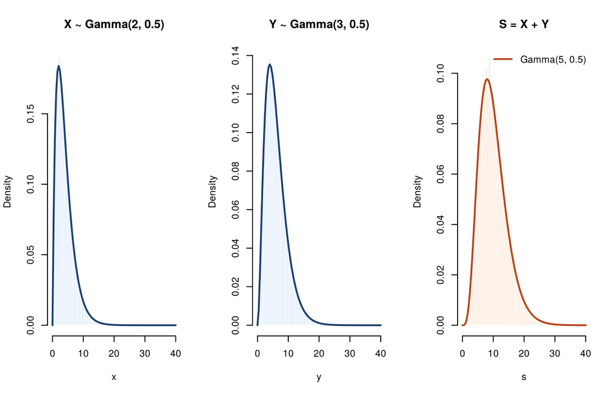

Figure 2. Histograms of X, Y and S = X + Y with their theoretical Gamma densities overlaid.

```r
S2 <- X2 + Y2
par(mfrow = c(1, 3))
hist(X2, breaks = 60, freq = FALSE, col = "#d0e1f9", border = "white",
     main = "X ~ Gamma(2, 0.5)", xlab = "x", xlim = c(0, 40))
curve(dgamma(x, alphaX, rate), add = TRUE, lwd = 2, col = "#1b3f6b")
hist(Y2, breaks = 60, freq = FALSE, col = "#d0e1f9", border = "white",
     main = "Y ~ Gamma(3, 0.5)", xlab = "y", xlim = c(0, 40))
curve(dgamma(x, alphaY, rate), add = TRUE, lwd = 2, col = "#1b3f6b")
hist(S2, breaks = 60, freq = FALSE, col = "#f9dcc4", border = "white",
     main = "S = X + Y", xlab = "s", xlim = c(0, 40))
curve(dgamma(x, alphaX + alphaY, rate), add = TRUE, lwd = 2, col = "#b5441b")
legend("topright", legend = "Gamma(5, 0.5)", lwd = 2, col = "#b5441b", bty = "n")
```

```r
par(mfrow = c(1, 1))
```

The histogram of S is right-skewed, but less so than the histogram of X or Y. It is centered near 10, and it matches the theoretical Gamma(5, 0.5) density closely. Adding independent variables shifts the center to the right, spreads the distribution out, and makes the shape more symmetric, which is a first hint of the Central Limit Theorem.

```r
ks.test(S2, "pgamma", shape = alphaX + alphaY, rate = rate)
```

```
    Asymptotic one-sample Kolmogorov-Smirnov test

data:  S2
D = 0.0085899, p-value = 0.4518
alternative hypothesis: two-sided
```

The Kolmogorov–Smirnov test gives a large p-value, so the simulated S is consistent with Gamma(5, 0.5).

## 4.4 (d) Theoretical vs. simulated mean and variance

```r
theory <- c(E_X = alphaX/rate, E_Y = alphaY/rate, E_S = (alphaX + alphaY)/rate,
            V_X = alphaX/rate^2, V_Y = alphaY/rate^2, V_S = (alphaX + alphaY)/rate^2)
simul  <- c(mean(X2), mean(Y2), mean(S2), var(X2), var(Y2), var(S2))

moments <- data.frame(
  Quantity    = c("E[X]", "E[Y]", "E[S]", "Var(X)", "Var(Y)", "Var(S)"),
  Theoretical = as.numeric(theory),
  Simulated   = round(simul, 4),
  Abs_Error   = round(abs(simul - theory), 4)
)
moments
```

|  | Quantity | Theoretical | Simulated | Abs_Error |
| --- | --- | --- | --- | --- |
| E_X | E[X] | 4 | 3.9584 | 0.0416 |
| E_Y | E[Y] | 6 | 6.0194 | 0.0194 |
| E_S | E[S] | 10 | 9.9778 | 0.0222 |
| V_X | Var(X) | 8 | 7.9802 | 0.0198 |
| V_Y | Var(Y) | 12 | 12.0772 | 0.0772 |
| V_S | Var(S) | 20 | 19.7879 | 0.2121 |

```r
# Additivity checks on the simulated data
c(mean_X_plus_mean_Y = mean(X2) + mean(Y2), mean_S = mean(S2))
```

```
mean_X_plus_mean_Y             mean_S
           9.97781            9.97781
```

```r
c(var_X_plus_var_Y   = var(X2) + var(Y2),   var_S  = var(S2),
  two_cov_XY         = 2 * cov(X2, Y2))
```

```
var_X_plus_var_Y            var_S       two_cov_XY
      20.0573915       19.7878504       -0.2695411
```

**Table 6.** Theoretical vs. simulated moments of X, Y and S.

- **Mean:** the simulated E[S] = 9.978 is very close to the theoretical value 10. It also equals X̄ + Ȳ exactly, because E[X+Y] = E[X] + E[Y] holds for *any* two random variables, independent or not.
- **Variance:** the simulated Var(S) = 19.788 is very close to the theoretical value 20. In general, Var(X+Y) = Var(X) + Var(Y) + 2Cov(X,Y). Independence makes Cov(X,Y) = 0. Here Var(X)+Var(Y) = 7.98 + 12.077 = 20.057, and the sample covariance term is only 2 × sample Cov(X, Y) = -0.27. That term is pure sampling noise, since the population covariance is 0, so the variances add, up to a difference of about 1%.

**Conclusion for Part 2.** The results support the properties of sums of independent random variables. The means add, the variances add because the covariance is zero, and the sum of independent Gamma variables with a common rate is again Gamma, with shape α<sub>X</sub> + α<sub>Y</sub>.

# 5 Conditional Distributions – Discrete Case

Suppose a fair coin is tossed **5 times**. Let

- Y = the number of heads in the **first 3** tosses, so Y ∼ Binomial(3, 0.5);
- X = the **total** number of heads in all 5 tosses, so X = Y + Z with Z ∼ Binomial(2, 0.5) independent of Y, and X ∼ Binomial(5, 0.5).

Because X contains Y, the two variables are **dependent**, which makes conditioning informative.

```r
n3 <- 10000
Y3 <- rbinom(n3, 3, 0.5)                       # heads in first 3 tosses
Z3 <- rbinom(n3, 2, 0.5)                       # heads in last 2 tosses
X3 <- Y3 + Z3                                  # total heads in 5 tosses
```

## 5.1 (a) Joint probability distribution

```r
joint3 <- prop.table(table(X = factor(X3, levels = 0:5), Y = factor(Y3, levels = 0:3)))
round(joint3, 4)
```

```
   Y
X        0      1      2      3
  0 0.0323 0.0000 0.0000 0.0000
  1 0.0646 0.0938 0.0000 0.0000
  2 0.0323 0.1884 0.0903 0.0000
  3 0.0000 0.0948 0.1846 0.0316
  4 0.0000 0.0000 0.0940 0.0620
  5 0.0000 0.0000 0.0000 0.0313
```

```r
# Theoretical joint PMF: p(x, y) = P(Y = y) * P(Z = x - y)
joint3_theory <- outer(0:5, 0:3, function(x, y) dbinom(y, 3, 0.5) * dbinom(x - y, 2, 0.5))
dimnames(joint3_theory) <- list(X = 0:5, Y = 0:3)
round(joint3_theory, 4)
```

```
   Y
X        0      1      2      3
  0 0.0313 0.0000 0.0000 0.0000
  1 0.0625 0.0938 0.0000 0.0000
  2 0.0313 0.1875 0.0938 0.0000
  3 0.0000 0.0938 0.1875 0.0313
  4 0.0000 0.0000 0.0938 0.0625
  5 0.0000 0.0000 0.0000 0.0313
```

**Table 7.** Empirical joint PMF p̂<sub>X,Y</sub>(x,y), followed by the theoretical joint PMF p<sub>X,Y</sub>(x,y) = C(3, y)C(2, x-y)/2⁵.

Cells with x < y or x > y + 2 are exactly 0, because the total number of heads cannot be less than the heads in the first 3 tosses or more than 2 above it. The empirical table matches the theoretical one closely.

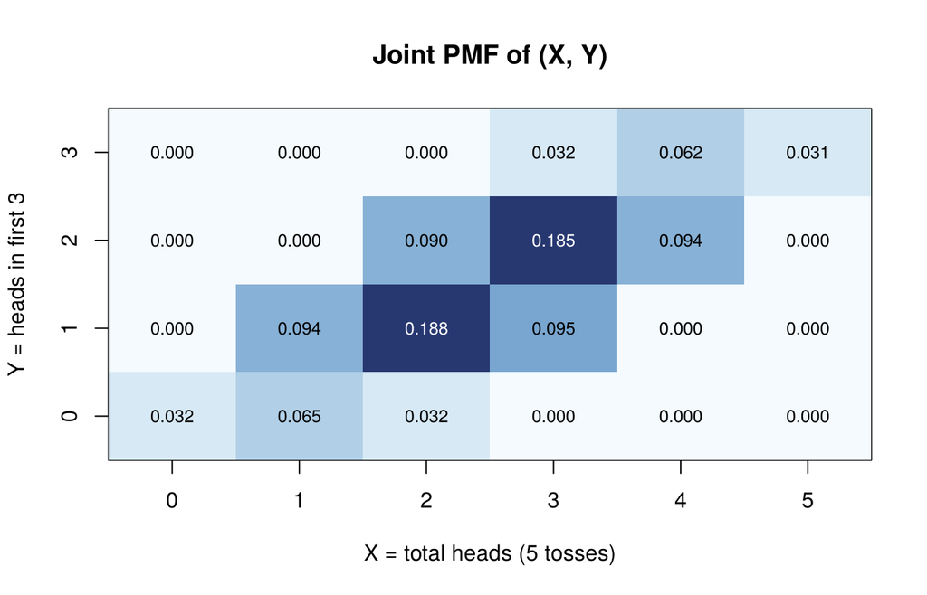

Figure 3. Empirical joint PMF of (X, Y). Darker cells have higher probability; zero cells lie off the diagonal band.

```r
image(0:5, 0:3, joint3, col = hcl.colors(20, "Blues", rev = TRUE),
      xlab = "X = total heads (5 tosses)", ylab = "Y = heads in first 3", main = "Joint PMF of (X, Y)")
text(rep(0:5, 4), rep(0:3, each = 6), sprintf("%.3f", joint3), cex = 0.8,
     col = ifelse(joint3 > 0.12, "white", "black"))
```

## 5.2 (b) Marginal distributions

```r
pX3 <- rowSums(joint3); pY3 <- colSums(joint3)
data.frame(x = 0:5, empirical_pX = round(as.numeric(pX3), 4), theoretical_pX = round(dbinom(0:5, 5, 0.5), 4))
```

| x | empirical_pX | theoretical_pX |
| --- | --- | --- |
| 0 | 0.0323 | 0.0312 |
| 1 | 0.1584 | 0.1562 |
| 2 | 0.3110 | 0.3125 |
| 3 | 0.3110 | 0.3125 |
| 4 | 0.1560 | 0.1562 |
| 5 | 0.0313 | 0.0312 |

```r
data.frame(y = 0:3, empirical_pY = round(as.numeric(pY3), 4), theoretical_pY = dbinom(0:3, 3, 0.5))
```

| y | empirical_pY | theoretical_pY |
| --- | --- | --- |
| 0 | 0.1292 | 0.125 |
| 1 | 0.3770 | 0.375 |
| 2 | 0.3689 | 0.375 |
| 3 | 0.1249 | 0.125 |

**Tables 8–9.** Marginal PMFs, obtained by summing the joint table across rows (p<sub>X</sub>(x)=Σ<sub>y</sub> p(x,y)) and down columns (p<sub>Y</sub>(y)=Σ<sub>x</sub> p(x,y)). They agree with Binomial(5, 0.5) and Binomial(3, 0.5).

## 5.3 (c) Conditional distribution of X given Y = 2

p<sub>X|Y</sub>(x | 2) = p<sub>X,Y</sub>(x, 2) / p<sub>Y</sub>(2)

```r
y0 <- 2
cond3        <- joint3[, as.character(y0)] / pY3[as.character(y0)]
cond3_theory <- dbinom(0:5 - y0, 2, 0.5)       # given Y = 2, X = 2 + Z
cond_table <- data.frame(x = 0:5,
                         conditional_emp    = round(as.numeric(cond3), 4),
                         conditional_theory = cond3_theory,
                         marginal_pX        = round(dbinom(0:5, 5, 0.5), 4))
cond_table
```

| x | conditional_emp | conditional_theory | marginal_pX |
| --- | --- | --- | --- |
| 0 | 0.0000 | 0.00 | 0.0312 |
| 1 | 0.0000 | 0.00 | 0.1562 |
| 2 | 0.2448 | 0.25 | 0.3125 |
| 3 | 0.5004 | 0.50 | 0.3125 |
| 4 | 0.2548 | 0.25 | 0.1562 |
| 5 | 0.0000 | 0.00 | 0.0312 |

```r
sum(cond3)                                     # a valid PMF sums to 1
```

```
[1] 1
```

```r
c(E_X = sum(0:5 * pX3), E_X_given_Y2 = sum(0:5 * cond3))
```

```
         E_X E_X_given_Y2
     2.49390      3.01003
```

```r
c(Var_X = sum((0:5)^2 * pX3) - sum(0:5 * pX3)^2,
  Var_X_given_Y2 = sum((0:5)^2 * cond3) - sum(0:5 * cond3)^2)
```

```
         Var_X Var_X_given_Y2
     1.2603628      0.4994928
```

**Table 10.** Conditional PMF of X given Y=2 (empirical and theoretical), compared with the unconditional marginal p<sub>X</sub>(x).

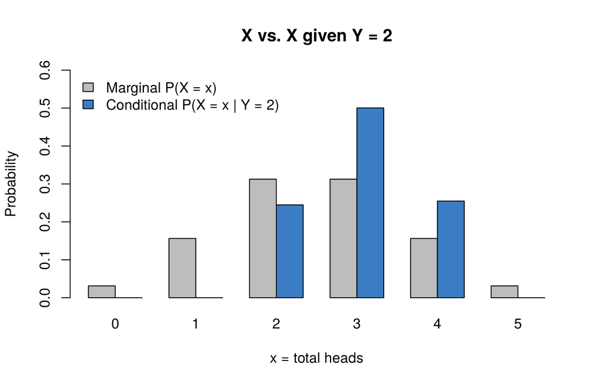

Figure 4. Marginal PMF of X compared with the conditional PMF of X given Y = 2.

```r
barplot(rbind(dbinom(0:5, 5, 0.5), as.numeric(cond3)), beside = TRUE, names.arg = 0:5,
        col = c("#bdbdbd", "#3b7dc4"), ylim = c(0, 0.6),
        legend.text = c("Marginal P(X = x)", "Conditional P(X = x | Y = 2)"),
        args.legend = list(x = "topleft", bty = "n"),
        xlab = "x = total heads", ylab = "Probability", main = "X vs. X given Y = 2")
```

## 5.4 (d) Interpretation

Without any information, X follows Binomial(5, 0.5). It is spread over {0,…,5} with mean 2.5 and variance 1.25.

Once we know Y = 2 (two heads in the first three tosses), the conditional distribution **changes sharply**:

- The values x = 0, 1, 5 become **impossible**, with conditional probability 0. The total must be at least 2 and at most 2 + 2 = 4.
- The remaining mass is {2, 3, 4} with probabilities close to 0.25, 0.50, 0.25. This is exactly the distribution of 2 + Z with Z ∼ Binomial(2, 0.5).
- The conditional mean rises to E[X | Y=2] = 3.01 (theory: 3). The conditional variance falls to about 0.499 (theory: 0.5), because only the last two tosses remain uncertain.

Because p<sub>X|Y</sub>(x | 2) ≠ p<sub>X</sub>(x), conditioning on Y changes the distribution of X, so **X and Y are not independent**. This is the opposite of Part 1, where conditioning on the die face left the coin-head distribution unchanged.

# 6 Conditional Distributions – Continuous Case

## 6.1 (a) Two continuous random variables

Let X = weekly **study hours** and Y = **exam score** for a class of students. Model them as **bivariate normal** with

μ<sub>X</sub> = 20, σ<sub>X</sub> = 5, μ<sub>Y</sub> = 75, σ<sub>Y</sub> = 10, ρ = 0.7.

A correlation of 0.7 means that students who study more tend to score higher, so the two variables are dependent.

```r
n4 <- 10000
muX <- 20; sdX <- 5; muY <- 75; sdY <- 10; rho <- 0.7
Sigma <- matrix(c(sdX^2, rho*sdX*sdY, rho*sdX*sdY, sdY^2), 2)
XY4 <- mvrnorm(n4, mu = c(muX, muY), Sigma = Sigma)
X4 <- XY4[, 1]; Y4 <- XY4[, 2]

data.frame(Variable = c("X (study hours)", "Y (exam score)"),
           Mean = round(c(mean(X4), mean(Y4)), 3),
           SD   = round(c(sd(X4), sd(Y4)), 3),
           Min  = round(c(min(X4), min(Y4)), 2),
           Max  = round(c(max(X4), max(Y4)), 2))
```

| Variable | Mean | SD | Min | Max |
| --- | --- | --- | --- | --- |
| X (study hours) | 20.047 | 5.035 | 0.69 | 38.99 |
| Y (exam score) | 75.082 | 10.080 | 36.91 | 110.76 |

```r
cor(X4, Y4)
```

```
[1] 0.70876
```

**Table 11.** Descriptive statistics of the simulated data. The sample means, SDs, and correlation (r = 0.709) all match the specified parameters.

## 6.2 (b) Marginal and joint distributions

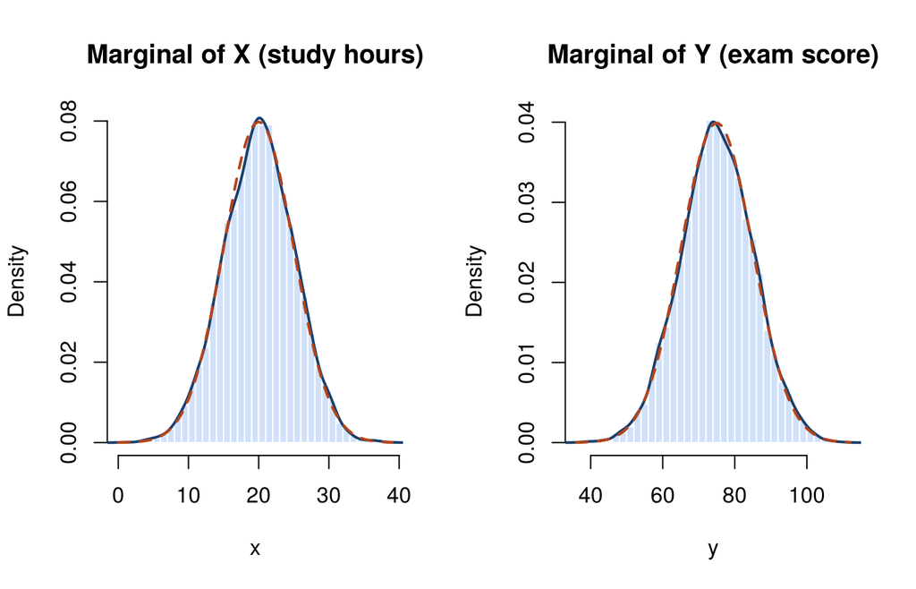

Figure 5. Marginal distributions of X and Y: histograms with kernel density estimates (solid) and theoretical normal densities (dashed).

```r
par(mfrow = c(1, 2))
hist(X4, breaks = 50, freq = FALSE, col = "#d0e1f9", border = "white",
     main = "Marginal of X (study hours)", xlab = "x")
lines(density(X4), lwd = 2, col = "#1b3f6b")
curve(dnorm(x, muX, sdX), add = TRUE, lwd = 2, lty = 2, col = "#b5441b")
hist(Y4, breaks = 50, freq = FALSE, col = "#d0e1f9", border = "white",
     main = "Marginal of Y (exam score)", xlab = "y")
lines(density(Y4), lwd = 2, col = "#1b3f6b")
curve(dnorm(x, muY, sdY), add = TRUE, lwd = 2, lty = 2, col = "#b5441b")
```

```r
par(mfrow = c(1, 1))
```

Both marginals are bell-shaped and symmetric: X ∼ N(20, 5²) and Y ∼ N(75, 10²). The kernel density estimates sit on top of the theoretical curves.

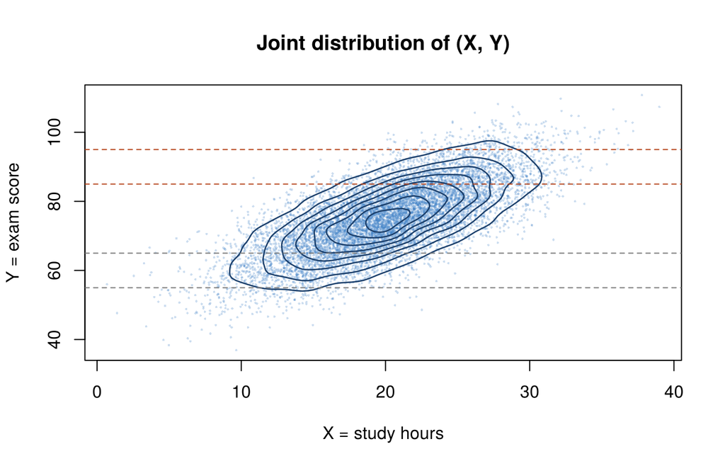

Figure 6. Joint distribution of (X, Y): scatter plot with 2-D kernel density contours. The tilted elliptical contours show positive dependence.

```r
dens2d <- kde2d(X4, Y4, n = 100)
plot(X4, Y4, pch = 16, cex = 0.3, col = adjustcolor("#3b7dc4", 0.25),
     xlab = "X = study hours", ylab = "Y = exam score", main = "Joint distribution of (X, Y)")
contour(dens2d, add = TRUE, drawlabels = FALSE, col = "#1b3f6b", lwd = 1.3)
abline(h = c(85, 95), lty = 2, col = "#b5441b"); abline(h = c(55, 65), lty = 2, col = "#7a7a7a")
```

The joint density has **elliptical contours tilted upward**. If X and Y were independent, f<sub>X,Y</sub>(x,y) = f<sub>X</sub>(x)f<sub>Y</sub>(y) and the contours would be axis-aligned. The tilt shows that the joint density does **not** factor into the product of the marginals. The dashed horizontal bands mark the slices of Y used in part (c).

## 6.3 (c) Empirical conditional distribution of X given an interval of Y

Y is continuous, so P(Y = y) = 0. Instead, we condition on narrow intervals: a **high-score** band 85 ≤ Y ≤ 95 and a **low-score** band 55 ≤ Y ≤ 65.

For a bivariate normal, theory gives

X | Y = y ∼ N(μ<sub>X</sub> + ρ(σ<sub>X</sub> / σ<sub>Y</sub>)(y - μ<sub>Y</sub>), σ<sub>X</sub>²(1-ρ²)).

```r
hi <- X4[Y4 >= 85 & Y4 <= 95]
lo <- X4[Y4 >= 55 & Y4 <= 65]
cond_mean <- function(y) muX + rho * sdX / sdY * (y - muY)   # E[X | Y = y]
cond_sd   <- sdX * sqrt(1 - rho^2)                          # SD[X | Y = y]

# Theory for a band a <= Y <= b: Y restricted to the band is a truncated normal,
# E[X | band]   = cond_mean(E[Y | band])
# Var(X | band) = cond_sd^2 + (rho * sdX / sdY)^2 * Var(Y | band)
band_theory <- function(a, b) {
  za <- (a - muY) / sdY; zb <- (b - muY) / sdY
  Z  <- pnorm(zb) - pnorm(za)
  mY <- muY + sdY * (dnorm(za) - dnorm(zb)) / Z
  vY <- sdY^2 * (1 + (za * dnorm(za) - zb * dnorm(zb)) / Z - ((dnorm(za) - dnorm(zb)) / Z)^2)
  c(EY = mY, mean = cond_mean(mY), sd = sqrt(cond_sd^2 + (rho * sdX / sdY)^2 * vY))
}
th_lo <- band_theory(55, 65); th_hi <- band_theory(85, 95)

data.frame(Group = c("All students (marginal)", "Low score: Y in [55, 65]", "High score: Y in [85, 95]"),
           n                 = c(length(X4), length(lo), length(hi)),
           Empirical_mean    = round(c(mean(X4), mean(lo), mean(hi)), 3),
           Theoretical_mean  = round(c(muX, th_lo["mean"], th_hi["mean"]), 3),
           Empirical_SD      = round(c(sd(X4), sd(lo), sd(hi)), 3),
           Theoretical_SD    = round(c(sdX, th_lo["sd"], th_hi["sd"]), 3))
```

| Group | n | Empirical_mean | Theoretical_mean | Empirical_SD | Theoretical_SD |
| --- | --- | --- | --- | --- | --- |
| All students (marginal) | 10000 | 20.047 | 20.000 | 5.035 | 5.000 |
| Low score: Y in [55, 65] | 1334 | 15.119 | 15.159 | 3.633 | 3.693 |
| High score: Y in [85, 95] | 1401 | 24.875 | 24.841 | 3.564 | 3.693 |

**Table 12.** Empirical vs. theoretical conditional means and SDs of X. The theoretical values account for the full width of each band. Inside a band, Y is not uniform: more students sit on the side closer to the overall mean of 75. So the average Y is 61.17 in the low band and 88.83 in the high band, not exactly the midpoints 60 and 90.

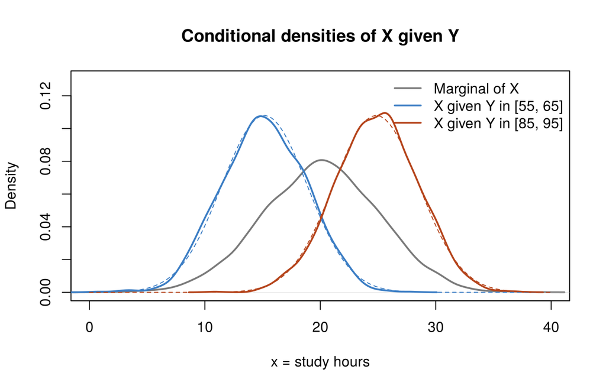

Figure 7. Empirical conditional densities of X (study hours) for low-score and high-score students, compared with the marginal density of X. Dashed lines are the theoretical conditional normals.

```r
plot(density(X4), lwd = 2, col = "#7a7a7a", ylim = c(0, 0.13), xlim = c(0, 40),
     main = "Conditional densities of X given Y", xlab = "x = study hours")
lines(density(lo), lwd = 2, col = "#3b7dc4")
lines(density(hi), lwd = 2, col = "#b5441b")
curve(dnorm(x, th_lo["mean"], th_lo["sd"]), add = TRUE, lty = 2, col = "#3b7dc4")
curve(dnorm(x, th_hi["mean"], th_hi["sd"]), add = TRUE, lty = 2, col = "#b5441b")
legend("topright", bty = "n", lwd = 2, col = c("#7a7a7a", "#3b7dc4", "#b5441b"),
       legend = c("Marginal of X", "X given Y in [55, 65]", "X given Y in [85, 95]"))
```

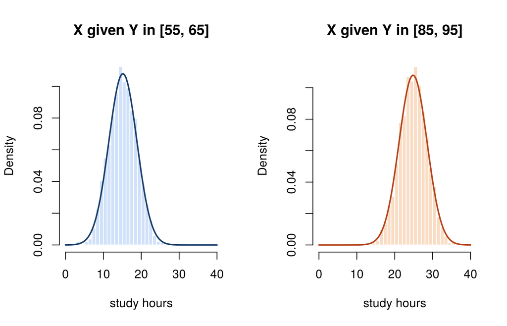

Figure 8. Histograms of X within each Y band.

```r
par(mfrow = c(1, 2))
hist(lo, breaks = 30, freq = FALSE, col = "#d0e1f9", border = "white", xlim = c(0, 40),
     main = "X given Y in [55, 65]", xlab = "study hours")
curve(dnorm(x, th_lo["mean"], th_lo["sd"]), add = TRUE, lwd = 2, col = "#1b3f6b")
hist(hi, breaks = 30, freq = FALSE, col = "#f9dcc4", border = "white", xlim = c(0, 40),
     main = "X given Y in [85, 95]", xlab = "study hours")
curve(dnorm(x, th_hi["mean"], th_hi["sd"]), add = TRUE, lwd = 2, col = "#b5441b")
```

```r
par(mfrow = c(1, 1))
```

## 6.4 (d) Interpretation

The conditional density is the joint density along the slice Y = y, rescaled so that it integrates to 1:

f<sub>X|Y</sub>(x | y) = f<sub>X,Y</sub>(x, y) / f<sub>Y</sub>(y).

Selecting the students with Y in a narrow band and plotting their X values is the empirical version of this operation: we take the slice of the scatter plot and renormalize it.

Conditioning on Y affects the distribution of X in two ways:

1. **Location shifts.** High scorers (85 ≤ Y ≤ 95) study about 24.88 hours on average, and low scorers (55 ≤ Y ≤ 65) study about 15.12 hours. Students overall average 20.05 hours. This follows the regression line E[X | Y = y] = 20 + 0.35(y − 75). At the average Y inside each band, the line gives 24.84 and 15.16 hours, which agree with the simulated means to within about 0.05 hours.
2. **Spread shrinks.** The conditional SDs are 3.63 (low band) and 3.56 (high band), well below the marginal SD of 5. At an exact value Y = y, the theoretical conditional SD is σ<sub>X</sub>√(1 − ρ²) = 3.571. A band of width 10 adds a little extra spread, because Y still varies inside the band, so the band theory gives about 3.69. Both empirical SDs are close to that value. The gaps are about one to two standard errors (SE ≈ 0.07 with about 1,300–1,400 students per band), which is normal sampling variation. Knowing the exact score removes a fraction ρ² = 0.49 of the variance of study hours.

Because f<sub>X|Y</sub>(x| y) depends on y, it differs from f<sub>X</sub>(x), and therefore f<sub>X,Y</sub>(x,y) ≠ f<sub>X</sub>(x)f<sub>Y</sub>(y). **X and Y are dependent.** If ρ were 0, all three curves in Figure 7 would coincide, and conditioning on Y would change nothing, as with the independent die and coins in Part 1.

# 7 Conclusion

- **Independence (Part 1).** For the die and the coins, the joint PMF equals the product of the marginals within sampling error (largest gap 0.0067, chi-square p = 0.197), so the factorization criterion holds and the variables are independent. A deliberately dependent pair breaks the criterion.
- **Sums (Part 2).** For independent Gamma variables, the simulated mean (9.978) and variance (19.788) of S = X + Y match the theoretical values 10 and 20. Means add for any variables. Variances add because independence makes the covariance zero. The sum is Gamma(5, 0.5).
- **Discrete conditioning (Part 3).** Knowing Y = 2 heads in the first three tosses reshapes the distribution of the total X. Support shrinks to {2,3,4}, the mean rises from 2.5 to about 3, and the variance falls from 1.25 to about 0.5. This shows that X and Y are dependent.
- **Continuous conditioning (Part 4).** For the bivariate normal pair, slices of the joint density show that X | Y shifts along the regression line and has a smaller spread (σ<sub>X</sub>√(1 − ρ²) = 3.57 at an exact y, versus 5 overall), as f<sub>X|Y</sub> = f<sub>X,Y</sub>/f<sub>Y</sub> predicts.

Overall, independence means that conditioning has no effect: f<sub>X|Y</sub>(x| y) = f<sub>X</sub>(x) for every y. Dependence means that the conditional distribution varies with the value being conditioned on.

# 8 References

- R Core Team (2024). *R: A Language and Environment for Statistical Computing*. R Foundation for Statistical Computing, Vienna, Austria. https://www.R-project.org/
- Venables, W. N., & Ripley, B. D. (2002). *Modern Applied Statistics with S* (4th ed.). Springer. (R package **MASS**: `mvrnorm()`, `kde2d()`.)
- Xie, Y., Allaire, J. J., & Grolemund, G. (2018). *R Markdown: The Definitive Guide*. Chapman & Hall/CRC. https://bookdown.org/yihui/rmarkdown/
- APM1110 Module 7 – Conditional Distributions and Stochastic Independence (course material).